# HW8

Claire

2019年4月23日

### 空間分析 HW8

#### 地理二 b06208028 甘佳昀

```r
library(rgdal)
library(spatstat)
library(ggplot2)
library(GISTools)
School <- readOGR(dsn = ".", layer = "Schools", encoding="utf8")
```

#### K function

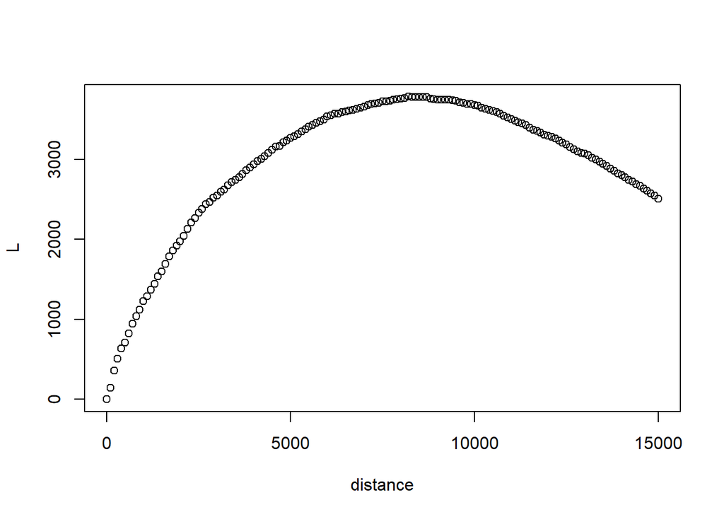

```r
bnd<-bbox(School)
x.coor<-School$coords.x1
y.coor<-School$coords.x2
x.range<-bnd[1,]
y.range<-bnd[2,]
x<-x.range[2]-x.range[1]
y<-y.range[2]-y.range[1]
sqr.area<- x*y
densi<-nrow(School@data)/sqr.area
gap<-seq(0,15000,100)
L_list<-c(1:151)
dis<-c(1:151)

for(i in 1:length(gap)){
sch.b <- gBuffer(School, width = gap[i], byid = T, id = School$SCHOOL_ID)
sch.count <- poly.counts(School, sch.b)-1
k<-sum(sch.count)/nrow(School@data)
k<-k/densi
L<-sqrt(k/pi)-gap[i]
L_list[i]<-L
dis[i]<-gap[i]
}
Ktest<-data.frame(L_list,dis)
plot(Ktest$dis,Ktest$L_list,xlab='distance',ylab="L")
```

#### Envelope

```r
bnd<-bbox(School)
x.coor<-School$coords.x1
y.coor<-School$coords.x2
x.range<-bnd[1,]
y.range<-bnd[2,]

School.ppp<-ppp(x.coor,y.coor,x.range,y.range)

CI=envelope(School.ppp, Lest, nsim=99, nrank=1)
```

```
## Generating 99 simulations of CSR  ...
## 1, 2, 3, 4, 5, 6, 7, 8, 9, 10, 11, 12, 13, 14, 15, 16, 17, 18, 19, 20, 21, 22, 23, 24, 25, 26, 27, 28, 29, 30, 31, 32, 33, 34, 35, 36, 37, 38,
## 39, 40, 41, 42, 43, 44, 45, 46, 47, 48, 49, 50, 51, 52, 53, 54, 55, 56, 57, 58, 59, 60, 61, 62, 63, 64, 65, 66, 67, 68, 69, 70, 71, 72, 73, 74, 75, 76,
## 77, 78, 79, 80, 81, 82, 83, 84, 85, 86, 87, 88, 89, 90, 91, 92, 93, 94, 95, 96, 97, 98,  99.
##
## Done.
```

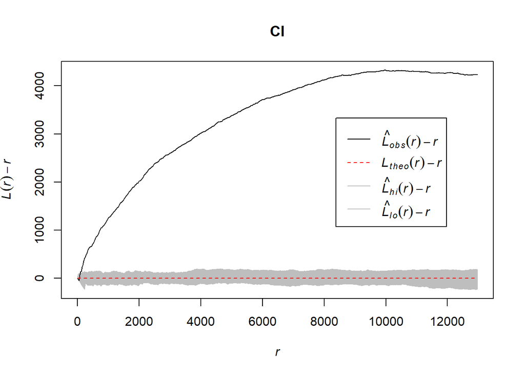

```r
plot(CI,.-r~r)
```

### 研讀期刊論文

#### **Table1.**

##### 描述了各個國家的smart cards嘉惠使用者方面，非直接在票價上做優惠或是使使用者獲利，而是用間接與其他商家合作提供使用者利益的案例。包括哪些地方推出了這樣的嘉惠方式，是怎麼樣功能、結合了甚麼優惠或福利的卡以及這些卡帶來的效益。這張表格顯示了smart cards在許多國家以跟commercial partners合作的方式提高並穩固了使用smart cards的客群。

#### **Table2.**

##### 描述了研究範圍內（Greater Montreal Area）使用大眾交通運輸工具的人們的不同特質以及相同特質的人搭乘不同運輸工具的比例。從這張表格可以知道使用大眾交通運輸的人們年齡、性別或是家庭型態的不同跟選擇不同交通運輸工具之間的關係。可以較清楚地了解什麼樣特質的乘客會是甚麼交通工具的重要消費者。

#### **Figure1.**

##### 這張圖顯示了在Montreal的捷運站分布。而這些捷運站的分布除了能顯示捷運路線的大致型態以外，與站點附近商家分布互相比對跟分析也能發現商家分布在捷運站附近是否有聚集的情況。

#### **Figure2**

##### 使用F-function顯示了真實捷運站點分布跟商家分布的距離關係以及使用隨機分布模擬的捷運站和商家分布的差異。從圖中可以看出在真實資料下，約80%的捷運站附近100公尺範圍內有可合作的商家；超過90%在捷運站附近200公尺範圍內有可合作的商家。並且在一開始，真實情況的曲線比隨機分布99%信心水準區間上下限的曲線上升速度還要快，代表著許多捷運站附近的距離內就有商家存在。這些都顯示了商家聚集在捷運站周遭的狀況是明顯的。

#### **Figure3**

##### 這張圖針對了商家的種類做了F-function。結果顯示捷運站附近聚集的商家中最多的是餐廳，其次是雜貨店跟美容店。其中有70%的捷運站附近100公尺範圍內會出現餐廳，而無論哪一個捷運站，在方圓450公尺內都至少會出現一家餐廳。而80%的捷運站在方圓250公尺內會出現美容店跟雜貨店。但美容店跟雜貨店的空間聚集狀況從250公尺之後開始分歧，美容院在250公尺之後分布的比較稀疏。此外，日托中心、影片出租行跟加油站則是最不會聚集在捷運站周邊的商家，這或許跟他們的傾向為步行的人們提供服務的緣故。而這張圖根據商家的分類來細看商家在捷運站附近的分布情況，有助於挑選跟捷運當局一起合作的商業夥伴跟合作的形式。

#### **Table3.**

##### 這張表格顯示了各類型的商家之間在捷運站附近的聚集型態兩兩比對的相近度。利用Kolmogorov–Smirnov test來檢定任意兩者之間的相似度。表格中0的部分是虛無假設（也就是兩者相似）成立，1的部分則是對立假說成立。可以發現餐廳、美容店跟雜貨店的聚集型態相似，而日托中心、影片出租行跟加油站也是。這樣倆倆比對的目的是為了找出分布型態相似的店家類型，便可以繼續深入研究這些店家共有的特色。

#### **Figure4.**

##### 這張圖將四個空間分布差異較大的店家類型作更細的研究。它將餐廳、診所、銀行跟加油站之於捷運站第一近跟第四近的店家做F-function，並且比較他們之間的差異。可以發現餐廳無論是第一近的還是第四近的都離捷運站很近，但到了診所，這種特徵就消失了。之後的銀行跟加油站第一近跟第三近的差異則越來越大，也越來越不聚集。這樣的分析使得在尋找及洽談商業合作夥伴時會更容易和有效率。

#### **Figure5.**

##### 描述了不同年齡區間以及收入的客群在不同的距離內對於某餐廳的曝光人次。可以看出在年齡為26～46之間並且收入在CAD 20,000以上的客群在很近的距離下就可以到達餐廳，是屬於餐廳容易曝光到的對象。而65歲以上的老年人則為餐廳最不容易曝光到的對象。了解這些客群的特質有助於尋找商業夥伴跟制定相關的優惠措施。

#### **Figure6.**

##### 這兩張圖顯示了兩個不同的乘客客群在各個車站的流量。其中年紀較小，收入較低的客群主要流量分布在幾個確定的車站，其中有兩個跟高等教育機構有關；而另外一群較年長，收入較高的客群流量則較廣泛的分布。這樣的資料可以幫助擬訂針對特定客群的商業計畫，並且幫助這些計畫上的恰當選擇。

#### **閱讀心得**

##### 帶給人們生活上的便利的大眾運輸工具，常常是由政府提供的公共財。但是要如何在不虧損的狀況下繼續以平價的票價服務大眾是個難關。我認為本文很仔細的研究並敘述了smart card在大眾運輸上遇到的困境以及各種解決辦法，包含主要探討的商業合作模式，並利用空間分析的形式來找尋站點附近個型態商家的聚集情況和彼此的關係。我認為這份研究如果以台北或是高雄捷運的尺度來做的話或許也能增益不少，不過由於台灣有特別密集，跟人們生活息息相關的便利商店產業。如果能在研究中加入有關便利商店在站點附近聚集程度的研究，也許會有更令人感興趣的結果，也會更適合台灣的大眾運輸作為建立商業合作夥伴跟政策的參考。